# Лабораторная работа №6

Основы интерфейса взаимодействия пользователя с системой Unix на уровне командной строки

Липатников Андрей

1032253853@rudn.ru

Российский университет дружбы народов

2026-10-08

# Информация

## Докладчик

- Липатников Андрей
- Студент Российского университета дружбы народов им. П. Лумумбы
- 1032253853@rudn.ru

# Вводная часть

## Актуальность

- Командная строка — основной инструмент взаимодействия с системой Unix
- Владение командами необходимо для администрирования и автоматизации
- Навыки, полученные в этой работе, используются во всех последующих лабораторных
- Цель презентации: показать процесс выполнения и подтвердить освоение базовых команд

## Объект и предмет исследования

- **Объект**: интерфейс взаимодействия пользователя с системой Unix
- **Предмет**: команды командной строки (`cd`, `pwd`, `ls`, `mkdir`, `rm`, `rmdir`, `man`, `history`)
- **Критерий результата**: освоены команды и их опции, зафиксированы скриншотами

## Цели и задачи

- Цель:
  - Приобрести практические навыки взаимодействия с системой посредством командной строки
- Задачи:
  - Изучить команды `cd`, `pwd`, `ls`, `mkdir`, `rm`, `rmdir`, `man`, `history`
  - Освоить опции команд (`ls -a`, `ls -la`, `ls -R`, `ls -lt`, `rm -r`, `rmdir`, `mkdir -p`)
  - Научиться работать с историей команд и модифицировать команды из буфера

# Материалы и методы

## Используемое ПО и среда

- **ОС**: Fedora 41 (Sway) в VirtualBox
- **Терминал**: bash
- **Инструменты**: `man`, `cd`, `pwd`, `ls`, `mkdir`, `rm`, `rmdir`, `history`

## Методика выполнения

- Изучение справок команд через `man`
- Выполнение практических заданий из методички
- Фиксация каждого шага скриншотом
- Анализ разницы вывода команд с разными опциями
- Модификация команд из буфера истории (`!<номер>:s/<что>/<на_что>`)

# Содержание исследования

## Определение домашнего каталога

- Команда `pwd` выводит полный путь к текущему каталогу

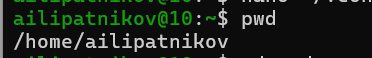

## Переход в /tmp

- Команда `cd /tmp` меняет текущий каталог

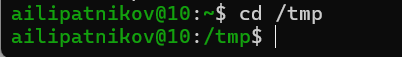

## Содержимое /tmp: ls

- Команда `ls` показывает имена файлов без подробностей

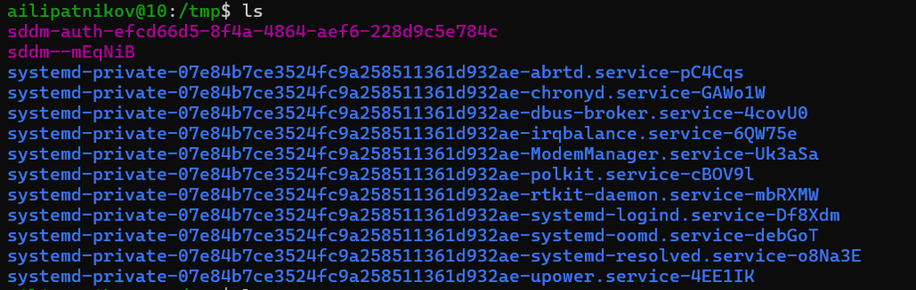

## Содержимое /tmp: ls -a

- Опция `-a` показывает скрытые файлы (начинаются с точки)

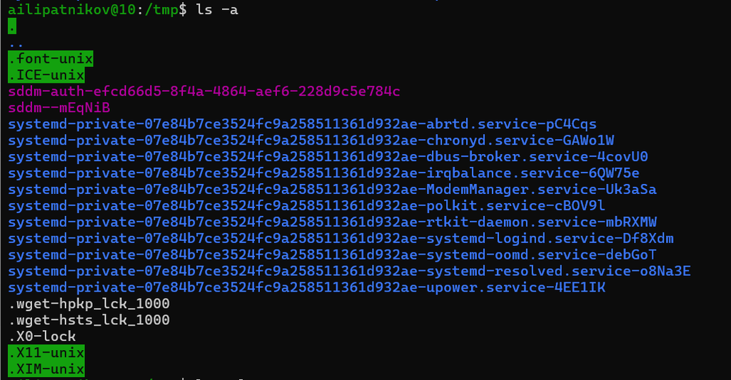

## Содержимое /tmp: ls -la

- Опция `-l` — подробный вывод, `-a` — скрытые файлы

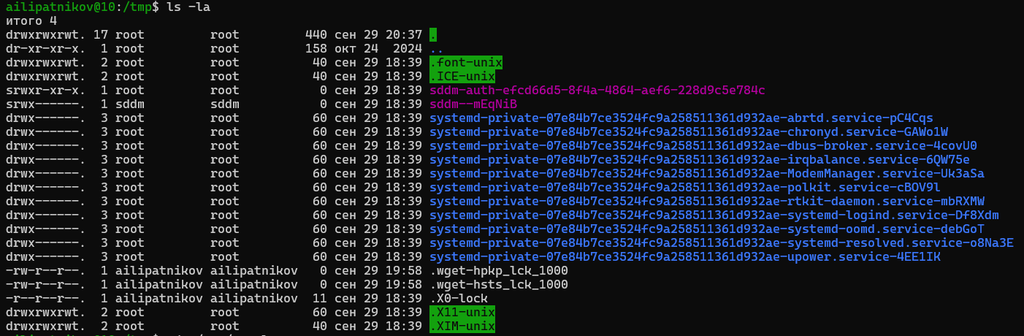

## Проверка /var/spool на cron

- В каталоге /var/spool есть подкаталог cron

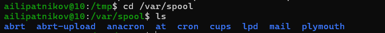

## Домашний каталог и владельцы

- Команда `ls -la` в домашнем каталоге показывает владельца файлов

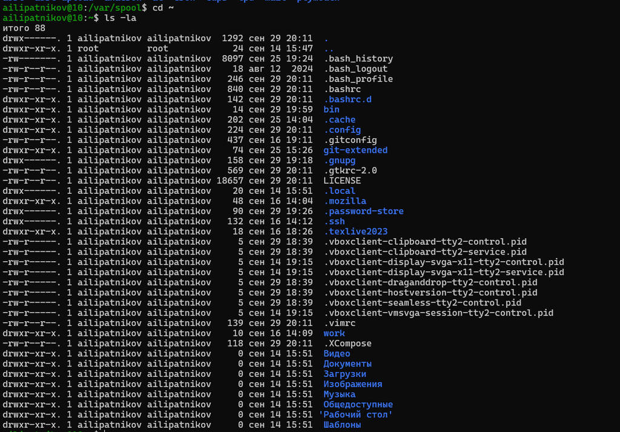

## Создание newdir

- Команда `mkdir newdir` создаёт каталог в домашнем каталоге

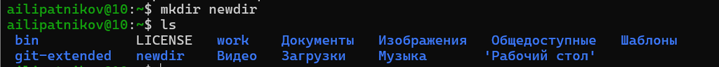

## Создание morefun в ~/newdir

- Вложенный каталог создан командой `mkdir morefun`

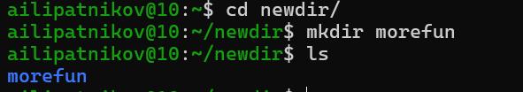

## Создание и удаление трёх каталогов

- `mkdir letters memos misk` создаёт сразу три каталога
- `rmdir letters memos misk` удаляет их

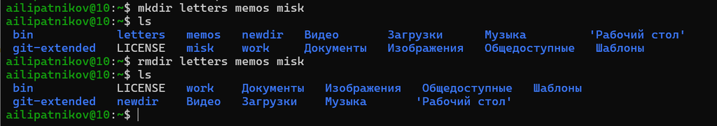

## Попытка удалить newdir командой rm

- `rm newdir` выдаёт ошибку: это каталог

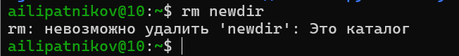

## Удаление ~/newdir/morefun

- Команда `rmdir newdir/morefun` удаляет пустой подкаталог

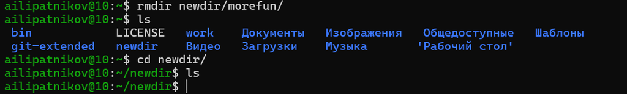

## Поиск опции ls -R

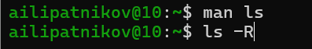

## Сортировка по времени: ls -lt

- Опция `-t` сортирует по времени последнего изменения содержимого
- Опция `-l` даёт развёрнутый вывод
- Итог: `ls -lt` (или `ls -ltr` для обратного порядка)

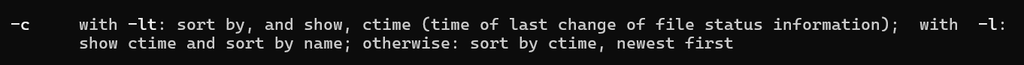

## Справки: man pwd и man cd

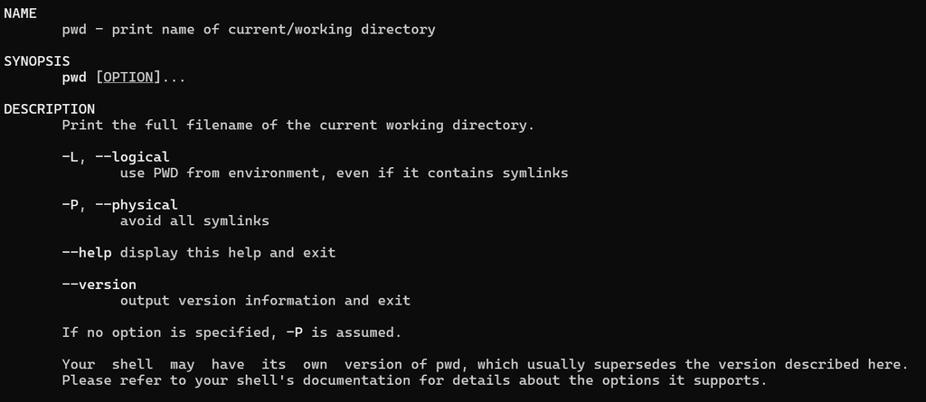

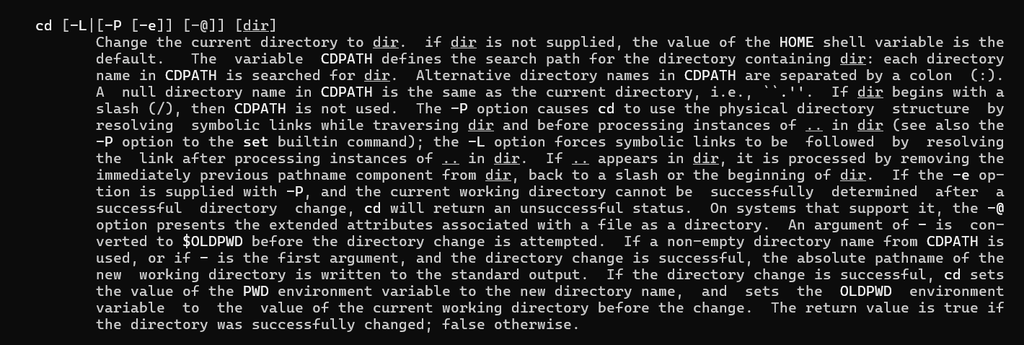

## Справки: man mkdir и man rmdir

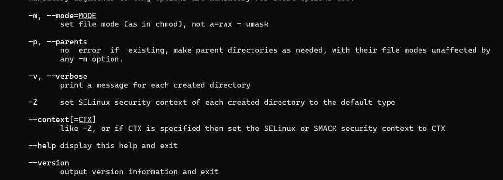

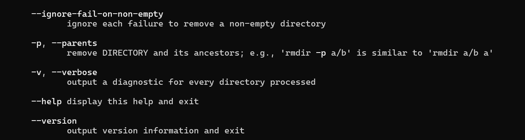

## Справка man rm

- Опции: -f, -i, -I, -r, -d, -v

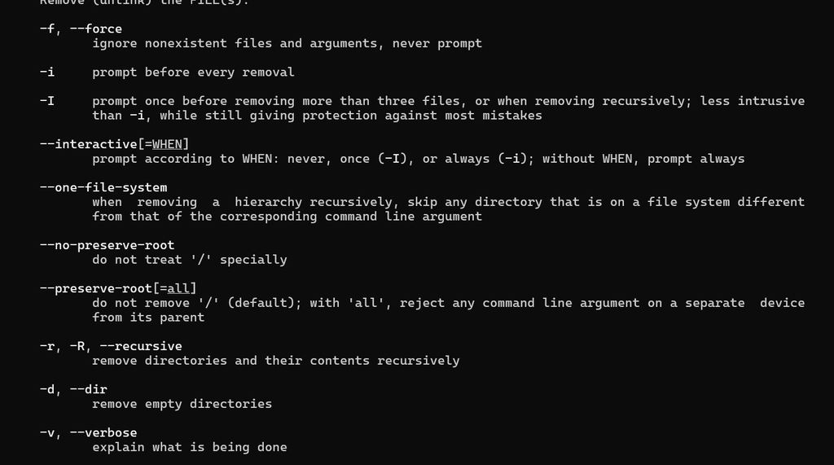

## Модификация команд через history

- Команда `history` показывает список выполненных команд с номерами
- Модификация и повторное выполнение: `!<номер>:s/<что>/<на_что>`
- Результат модификации: `rm -r newdir` и `pwd -L`

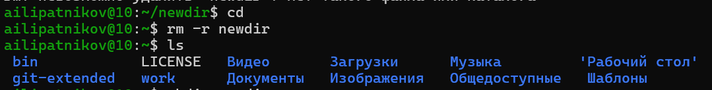

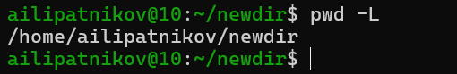

# Результаты

## Полученные результаты

- Освоены команды работы с файловой системой и их опции

| Результат | Значение |
| --- | --- |
| Навигация | `cd`, `pwd` (`-L`, `-P`) |
| Просмотр | `ls` (`-a`, `-l`, `-la`, `-R`, `-lt`) |
| Создание | `mkdir` (несколько аргументов, `-p`, `-m`) |
| Удаление | `rm` (`-r`, `-f`, `-i`), `rmdir` (только пустые) |
| История | `history`, `!<номер>:s/<что>/<на_что>` |

# Заключение

## Главный вывод

Освоены базовые команды командной строки Unix, их опции и работа со справкой через `man`. Полученные навыки — фундамент для всех последующих лабораторных работ курса.